# Phylogenetic pipeline for 48 Zaremba marker set

# General info

Objective: Run phylogenetic analyses using a custom set of reference genomes and using a set of 48 markers established by Zaremba et al., 2017.

General notice: The most important thing is a well named a short but descriptive genome name (DO NOT USE ‘-’ and limit use of other symbols). For the set of reference genomes I chose to use the GCA_XXX number as point of reference and I add it into the fasta header in step 3.

To add a more helpful name including the taxonomy I have a mapping file (current reference set for the archaea is v5 and for bacteria is v5)

## Version programs

- prokka 1.14-dev
- Python 2.7.5
- perl v5.16.3
- HMMER 3.1b2
- iqtree/2.1.1
- MAFFT v7.407
- BMGE-1.12

## Files/Databases needed

- 48_arcogs
- All_Arcogs_2018.hmm

## External scripts needed

**perl**

- best_hmmer.pl (13 columns, relevant columns: 1, 5 (evalue), 6 (bitscore))
- screen_list_new.pl
- Replace_tree_names.pl
- catfasta2phyml.pl

## Files needed

# Setup working environment

## Connect to server

Change username to your personal username. If you do not have access to ada yet, contact Hans Malschaert.

```bash
#log into server
ssh username@server
```

Ideally you want to work within a screen (depending on your system of course) since several steps take a while to run especially if you have a large number of genomes.

## Define variables

```bash
wdir="/export/lv1/user/ndombrowski/Phylogeny_tutorial/48_markers"

cpus=10

perl_scripts="/export/data01/tools/scripts/perl"

db_path='/export/data01/databases/arCOG/arCOGs2019/All_Arcogs_2018.hmm'
marker_list='/export/lv1/user/spang_team/Databases/48markers'
taxon_mapping='~/../spang_team/Databases/Archaea_Reference_Set/names_to_replace_Nina'
```

Notice:

- The taxon_mapping file is optional but generating such a file will allow to add a more detailed taxon string into the tree files.
- The taxon_mapping file should have two columns, one with the orginal ID in the tree and second the name we want to have:

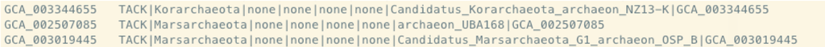

## Set working directory

```bash
#go to your home directory, or to wherever you want to work
cd $wdir
```

# 2. cp prokka protein files of reference genomes with genomes of interest

Notice:

- Adjust this part as needed for your own genomes
- ideally add the genome name into your fasta header (step 3 gives an example on how to do that if your genome name = file name)
- Ideally the header looks something like this: `>GCA_000008085-CALJACFG_00010`
  - avoid unneccassary symbols, such as spaces or dots
  - use `-` to separate the bin from the protienID
  - use `_` for other parts of the name
  - DO NOT use spaces
- You of course can use your own naming scheme but some parts of the workflow might need to be adjusted

## prepare a list of genomes we want to work with

```bash
mkdir FileLists

#add the list of genomes into this text doument
nano FileLists/Genomes_of_interest
```

The file we generate should look something like this:

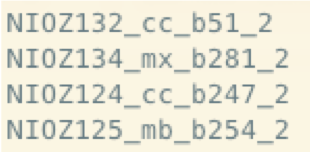

## Copy genomes of interest

```bash
mkdir faa
mkdir faa/single

#cp UAP2 reference Genomes
for sample in `cat FileLists/Genomes_of_interest`; do cp /export/lv1/user/spang_team/Projects/Alti_UPA2/prokka/faa/renamed/${sample}* faa/single; done

#cp UAP2 BS Genomes
for sample in `cat FileLists/Genomes_of_interest`; do cp /export/lv1/user/spang_team/Projects/BlackSea18/Prokka/V2/renamed/${sample}* faa/single; done

#control that we have all genomes --> 40 genomes
ll faa/single/* | wc -l

#concatenate genomes and clean fasta header
cat faa/single/*.faa > faa/All_Genomes.faa
cut -f1 -d " "  faa/All_Genomes.faa > faa/All_Genomes_clean.faa
gzip faa/single/*
```

The header should lool something like this: `>GCA_002494525-GCA_002494525_00010`

## Extra info: adding the file name (=genome name) into the fasta header

You only need to run this part of the code in case your genome name is not part of the fasta header

```bash
cd faa
mkdir renamed
for i in *faa; do awk '/>/{sub(">","&"FILENAME"|");sub(/\.faa/,x)}1' $i > renamed/$i; done
cd ..
```

# 4. search genes and clean up file names and extract proteins sequences

```bash
#add list of markers to wdir
cp $marker_list .

#prep folder for hmmsearch
mkdir Hmmersearch

#run search
hmmsearch --tblout Hmmersearch/sequence_results.txt -o Hmmersearch/results_all.txt --domtblout Hmmersearch/domain_results.txt --notextw --cpu $cpus $db_path  faa/All_Genomes.faa

#format the full table and only select sequences above a certain evalue
sed 's/ \+ /\t/g' Hmmersearch/sequence_results.txt | sed '/^#/d'| sed 's/ /\t/g'| awk -F'\t' -v OFS='\t' '{print $1, $3, $6, $5, $1}' | awk -F'\t' -v OFS='\t' '($4 + 0) <= 1E-3'  > Hmmersearch/sequence_results_red_e_cutoff.txt

#get best hit for each protein based on bit score, and then evalue, also add the binID into the first column
sort -t$'\t' -k3,3gr -k4,4g Hmmersearch/sequence_results_red_e_cutoff.txt | sort -t$'\t' --stable -u -k1,1  | sort -t$'\t' -k3,3gr -k4,4g | awk -F'\t' -v OFS='\t' '{split($1,a,"-"); print a[1], $5, $2, $3,$4}' >  Hmmersearch/All_markerss_hmm.txt

#separate the 51 marker genes into indiv. files
mkdir Hmmersearch/OGs

for sample in `cat  48_arcogs`; do grep "$sample" Hmmersearch/All_markerss_hmm.txt > Hmmersearch/OGs/${sample}.txt; done

ll Hmmersearch/OGs/*txt | wc -l
#51

#search and remove duplicates and keep only the best hit
#notice, in the initial best hit search we checked fo duplicated hits for an indiv. protein, now however,  we specifically search for gene duplications hmmsearchTable would not pick up because it compares the gene name and here we compare the genome name
mkdir Hmmersearch/deduplicated

for sample in `cat 48_arcogs`; do sort -t$'\t' -k4,4gr -k5,5g Hmmersearch/OGs/${sample}* | sort -t$'\t' --stable -u -k1,1 |  sort -t$'\t' -k4,4gr -k5,5g  > Hmmersearch/deduplicated/${sample}.txt ; done >> duplicated.txt

awk -F'\t' '{print $1}' TIGR03722.txt | sort | uniq -d

#get list of proteins to extract from faa file
mkdir Hmmersearch/protein_list

for sample in `cat  48_arcogs`; do awk -F'\t' -v OFS='\t' '{print $2 }' Hmmersearch/deduplicated/$sample* > Hmmersearch/protein_list/$sample |LC_ALL=C  sort ; done


#extract faa sequences
mkdir Marker_Genes
mkdir Marker_Genes/raw

for sample in `cat  48_arcogs`; do perl $perl_scripts/screen_list_new.pl Hmmersearch/protein_list/$sample faa/All_Genomes.faa keep > Marker_Genes/raw/${sample}.faa; done

#shorten header to be able to concatenate later (= remove protein ID)
mkdir Marker_Genes/renamed

for sample in `cat 48_arcogs`
do
cut -f1 -d "-" Marker_Genes/raw/$sample*>> Marker_Genes/renamed/${sample}.faa
done
```

# 6. Prepare alignment

Notice:

Adjust the parallel option (-j) according to the free cpus on ada, take care not to use more than 30% of the available cpus

## 6a. align with mafft_linsi

```bash
mkdir Alignment
mkdir Alignment/mafft_linsi

parallel -j2 'i={}; nice -n 10 mafft-linsi --reorder --thread 4 Marker_Genes/renamed/$i* > Alignment/mafft_linsi/${i}.aln ' ::: `cat 48_arcogs`
```

## 6b. Trim using BMGE

```bash
mkdir Alignment/BMGE
mkdir Alignment/BMGE/h0.55

parallel -j2 'i={}; nice -n 10 java -jar /opt/biolinux/BMGE-1.12/BMGE.jar -i Alignment/mafft_linsi/$i* -t AA -m BLOSUM30 -h 0.55 -of Alignment/BMGE/h0.55/$i ' :::  `cat 48_arcogs` >> trimming.txt
```

## 6c. concatenate single marker genes

Notice:

The marker set was established mainly on DPANN archaea, if you deal with new lineages you might want to also run the single gene trees and check them for issues with horizontal gene transfer.

```bash
mkdir Alignment/concatenated

perl $perl_scripts/catfasta2phyml.pl -f -c Alignment/BMGE/h0.55/* > Alignment/concatenated/48markers_ALR_DPANN_ArcRefv5_v1.faa
```

# 7. run iqtree

## single gene trees

```bash
mkdir Phylogeny
mkdir Phylogeny/single

#run trees
module load iqtree/2.1.1
parallel -j10 'i={}; iqtree2 -s Alignment/BMGE/h0.55/${i}.faa -m LG+C10+F+R  -nt 4 -wbtl -bb 1000 -bnni -pre Phylogeny/single/${i}' ::: `cat 48_arcogs`

#rename tree files and add taxon string
cd Phylogeny/single
parallel -j10 'i={}; perl $perl_scripts/Replace_tree_names.pl $taxon_mapping $i > ${i}_renamed' ::: *treefile
cd ../..
```

## concatenated tree

While in our experience the model below is good for the marker set used you might also want to run a model test.

```bash
mkdir Phylogeny/concat

cp Alignment/concatenated/48markers_ALR_DPANN_ArcRefv5_v1.faa Phylogeny/concat
cd Phylogeny/concat

#run iqtree
module load iqtree/2.1.1
iqtree2 -s 48markers_ALR_DPANN_ArcRefv5_v1.faa -m LG+C60+F+R -nt AUTO -bb 1000 -alrt 1000

#rename treefile for easier handling (mapping file available for v6 set)
perl $perl_scripts/Replace_tree_names.pl $taxon_mapping 48markers_ALR_DPANN_ArcRefv5_v1.faa.treefile > 48markers_ALR_DPANN_ArcRefv5_v1.faa.treefile_renamed
```

If you want to run a model test you HAVE TO add the C60 series manually.

```bash
iqtree2 -s alignment.aln -m MFP -madd LG+C10,LG+C20,LG+C30,LG+C40,LG+C50,LG+C60,LG+C10+R+F,LG+C20+R+F,LG+C30+R+F,LG+C40+R+F,LG+C50+R+F,LG+C60+R+F
```